# Homework 12

Hanusia Higgins

4/26/2020

For this exerise, use your newly-developed ggplot chops to create some nice graphs from your own data (If you do not have a good data frame to use for graphics, use one of the many built-in data frames from R (other than mpg, which we are using in class)). Experiment with different themes, theme base sizes, aesthetics, mappings, and faceting. When you are finished, try exporting them to high quality pdfs, jpgs, eps files, or other formats that you would use for submission to a journal.

In this exercise, I encourage you to improve your graphics with elements that we have not (yet) covered in ggplot. For example, can you change the labels on a facet plot so that they are more informative than the variable names that are supplied from your data frame? Can you figure out how to add text annotations, lines and arrows to your graph? Can you figure out how to use custom colors that you have chosen for your fills and lines? Your resources for these explorations are google, Stack Overflow – and Lauren!

```r
# preliminaries -------------------------------
library(ggplot2)
library(ggthemes)
library(datasets)
library(colorspace)
data("CO2") #using a built-in R dataset
d <- CO2
head(d)
```

```
##   Plant   Type  Treatment conc uptake
## 1   Qn1 Quebec nonchilled   95   16.0
## 2   Qn1 Quebec nonchilled  175   30.4
## 3   Qn1 Quebec nonchilled  250   34.8
## 4   Qn1 Quebec nonchilled  350   37.2
## 5   Qn1 Quebec nonchilled  500   35.3
## 6   Qn1 Quebec nonchilled  675   39.2
```

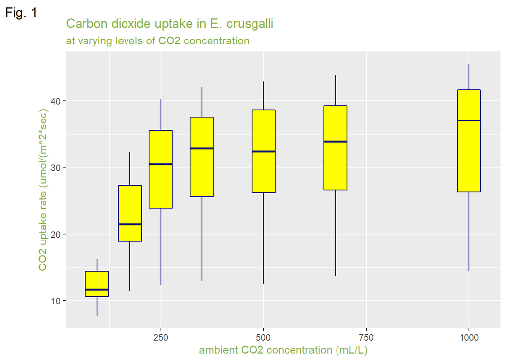

```r
##############################################

# Figure 1: Plotting CO2 uptake vs. concentration

# First modification: Custom colors for axis & plot titles
p1 <- ggplot(data=d,
             mapping=aes(x=conc,y=uptake, group=conc)) +
      geom_boxplot(
                 color="navy",fill="yellow") +
  labs(title="Carbon dioxide uptake in E. crusgalli",
           subtitle="at varying levels of CO2 concentration",
           x='ambient CO2 concentration (mL/L)',
           y='CO2 uptake rate (umol/(m^2*sec)',
       tag='Fig. 1') + #adding a corner "tag" such as numbering the figure
  # now, changing the colors of axis labels & plot titles
  theme(axis.title = element_text(colour="#88b04b"),
        plot.title = element_text(colour="#88b04b"),
        plot.subtitle=element_text(colour="#88b04b",))
print(p1)
```

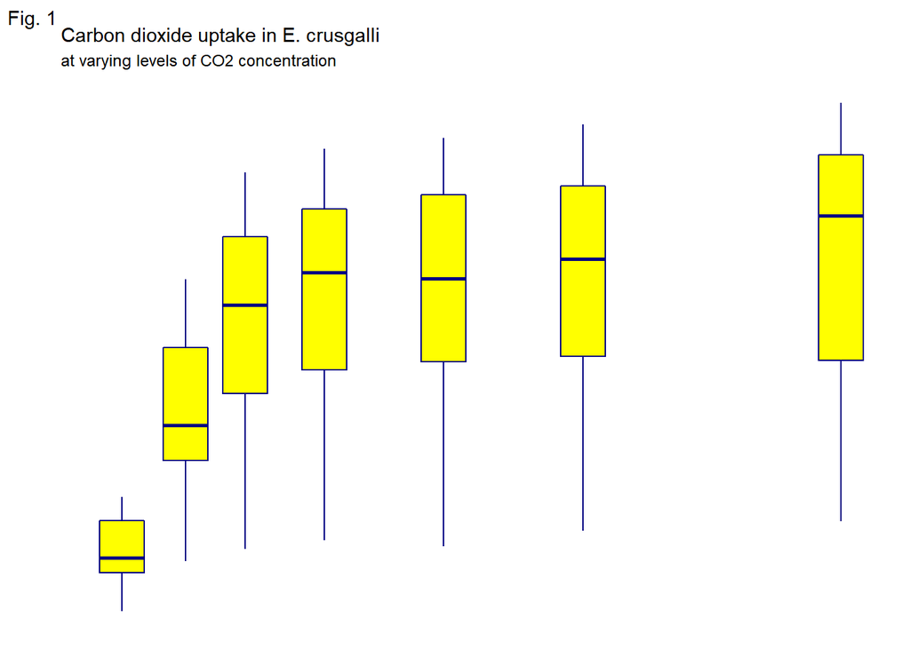

```r
# Trying on a few different themes:
p1 + theme_map()
```

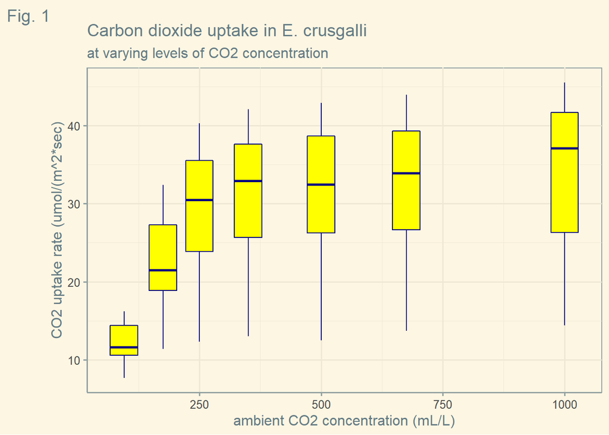

```r
p1 + theme_solarized()
```

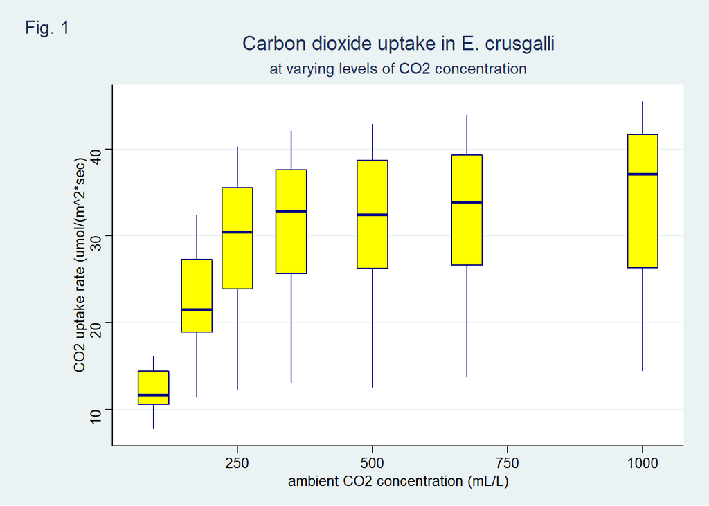

```r
p1 + theme_stata() # I like this one!
```

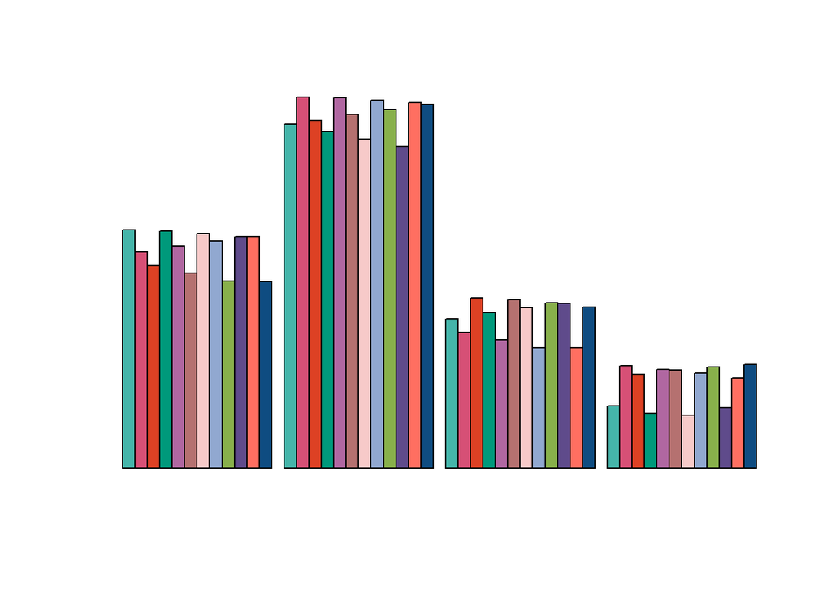

```r
#Now, coloring the different boxes with the Pantone color of the year
# of the past 10 years:

pantone_cols <- c('#45b5aa', #Turquoise- 2010
                  '#D65076', #Honeysuckle- 2011
                  '#dd4124', #Tangerine Tango- 2012
                  '#00997b', #Emerald- 2013
                  '#b067a1', #Radiant Orchid- 2014
                  '#B57170', #Marsala- 2015
                  '#f7cac9', #Rose Quartz- 2016-a
                  '#91A8d0', #Serenity- 2016-b
                  '#88b04b', #Greenery- 2017
                  '#5f4b8b', #Ultra Violet- 2018
                  '#ff6f61', #Living Coral- 2019
                  '#0f4c81' #Classic Blue- 2020
)

demoplot(pantone_cols, "bar")
```

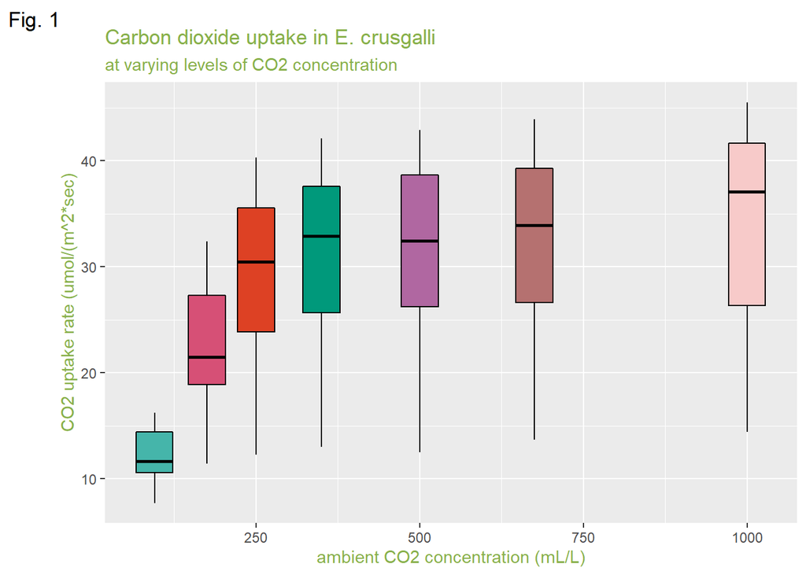

```r
p1 <- ggplot(data=d,
             mapping=aes(x=conc,y=uptake, group=conc)) +
      geom_boxplot(
                 color="black",fill=pantone_cols[1:7]) + #using a dif color for each box
  labs(title="Carbon dioxide uptake in E. crusgalli",
           subtitle="at varying levels of CO2 concentration",
           x='ambient CO2 concentration (mL/L)',
           y='CO2 uptake rate (umol/(m^2*sec)',
       tag='Fig. 1') + #adding a corner "tag" such as numbering the figure
  # now, changing the colors of axis labels & plot titles
  theme(axis.title = element_text(colour="#88b04b"),
        plot.title = element_text(colour="#88b04b"),
        plot.subtitle=element_text(colour="#88b04b",))
print(p1)
```